```python
# importing everything we need and loading the data
import pandas as pd
import numpy as np
import matplotlib.pyplot as plt

df = pd.read_csv("Sales Transaction v.4a.csv")
```

```python
# converting date column to datetime
df['Date'] = pd.to_datetime(df['Date'], format="%m/%d/%Y")

# creating month, year, and year-month columns
df['Year'] = df['Date'].dt.year
df['Month'] = df['Date'].dt.month
df['YearMonth'] = df['Date'].dt.to_period('M').astype(str)

# creating revenue column
df['Revenue'] = df['Price'] * df['Quantity']
```

```python
df_customer = df.dropna(subset=['CustomerNo']).copy()
df_customer['CustomerNo'] = df_customer['CustomerNo'].astype(int)
```

# Question 1

## How was the sales trend over the months?

```python
monthly_sales = (
    df.groupby('YearMonth', as_index=False)['Revenue']
      .sum()
      .sort_values('YearMonth')
)

monthly_sales.head(13)
```

|  | YearMonth | Revenue |
| --- | --- | --- |
| 0 | 2018-12 | 4234147.48 |
| 1 | 2019-01 | 3649506.42 |
| 2 | 2019-02 | 3299537.56 |
| 3 | 2019-03 | 4353308.78 |
| 4 | 2019-04 | 3416109.24 |
| 5 | 2019-05 | 4530850.36 |
| 6 | 2019-06 | 4410422.29 |
| 7 | 2019-07 | 4518347.92 |
| 8 | 2019-08 | 4614243.55 |
| 9 | 2019-09 | 6542706.30 |
| 10 | 2019-10 | 6971407.82 |
| 11 | 2019-11 | 7745257.92 |
| 12 | 2019-12 | 1994178.62 |

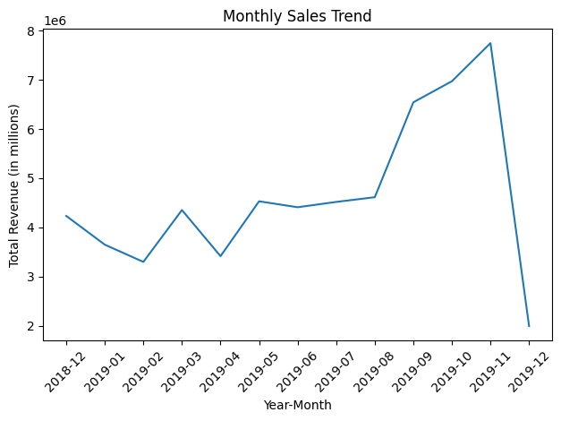

```python
plt.plot(monthly_sales['YearMonth'], monthly_sales['Revenue'])
plt.xticks(rotation=45)
plt.xlabel("Year-Month")
plt.ylabel("Total Revenue (in millions)")
plt.title("Monthly Sales Trend")
plt.tight_layout()
plt.show()
```

# Question 1 Answer:

### I started by aggregating sales by month using the YearMonth column. I then calculated the total revenue for each month. Plotting this lets us see whether the sales are stable, growing, or declining. After looking at the graph, you can see that sales were steadily increasing throughout the year, with a peak in November 2019 before dropping sharply the next month. This could be due to people ordering christmas gifts before christmas to ensure they will have the gifts. The same pattern is seen in Dec 2018, as the sales are on a decline at that time, although not as severe.

# Question 2

## What are the most frequently purchased products?

```python
product_qty = (
    df.groupby('ProductName', as_index=False)['Quantity']
      .sum()
      .sort_values('Quantity', ascending=False)
)

top_products = product_qty.head(10)
top_products
```

|  | ProductName | Quantity |
| --- | --- | --- |
| 2489 | Popcorn Holder | 56450 |
| 3685 | World War 2 Gliders Asstd Designs | 53847 |
| 1679 | Jumbo Bag Red Retrospot | 47363 |
| 204 | Assorted Colour Bird Ornament | 36445 |
| 2164 | Pack Of 72 Retrospot Cake Cases | 36231 |
| 828 | Cream Hanging Heart T-Light Holder | 35378 |
| 2549 | Rabbit Night Light | 30680 |
| 1945 | Mini Paint Set Vintage | 26437 |
| 2131 | Pack Of 12 London Tissues | 25907 |
| 2162 | Pack Of 60 Pink Paisley Cake Cases | 24753 |

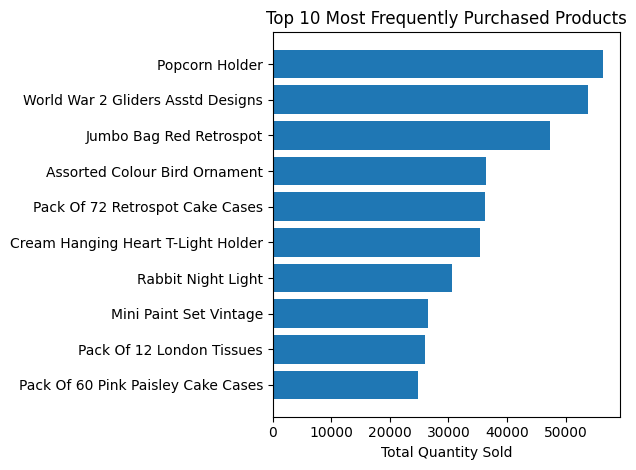

```python
plt.barh(top_products['ProductName'], top_products['Quantity'])
plt.xlabel("Total Quantity Sold")
plt.title("Top 10 Most Frequently Purchased Products")
plt.gca().invert_yaxis()
plt.tight_layout()
plt.show()
```

# Question 2 Answer

### In order to identify the most frequently purchased items, I summed the quantity sold for each product and ranked them from highest to lowest. Top products represent core items that take up large shares of volume, which could be useful for inventory planning. As seen in this chart, The top 3 most frequently purchased items are Popcorn Holders, World War 2 Gliders Asstd Designs, and Jumbo Bag Red Retrospot, in that order.

# Question 3

## How many products does the customer purchase in each transcation?

```python
products_per_txn = (
    df.groupby('TransactionNo')['ProductNo']
      .nunique()
      .reset_index(name='NumProducts')
)

products_per_txn['NumProducts'].describe()
```

```
count    23204.000000
mean        22.641226
std         44.148021
min          1.000000
25%          3.000000
50%         12.000000
75%         26.000000
max       1104.000000
Name: NumProducts, dtype: float64
```

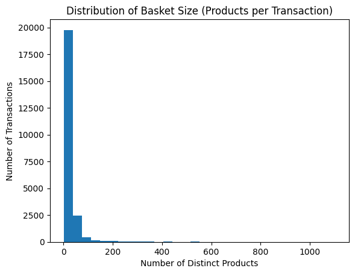

```python
plt.hist(products_per_txn['NumProducts'], bins=30)
plt.xlabel("Number of Distinct Products")
plt.ylabel("Number of Transactions")
plt.title("Distribution of Basket Size (Products per Transaction)")
plt.show()
```

# Question 3 Answer

### I grouped the data by transaction number to calculate how many distinct products each customer bought in a single order. The orderes contained an average of 23 items per order, although this number is likely a bit skewed from what the average person would order as there are single orders with hundreds of items. This can help the business understand their customers more, and whether or not they typically make small impulse purchases or large order with countless items.

# Question 4

## What are the most profitable segment customers?

```python
# Use only rows with a customer number
rfm_df = df_customer.copy()

# Reference date = last date in dataset
ref_date = rfm_df['Date'].max()

rfm = (
    rfm_df.groupby('CustomerNo')
    .agg(
        Recency=('Date', lambda x: (ref_date - x.max()).days),
        Frequency=('TransactionNo', 'nunique'),
        Monetary=('Revenue', 'sum')
    )
    .reset_index()
)



# Compute quartiles
r_quartiles = rfm['Recency'].quantile([0.25, 0.5, 0.75]).to_dict()
f_quartiles = rfm['Frequency'].quantile([0.25, 0.5, 0.75]).to_dict()
m_quartiles = rfm['Monetary'].quantile([0.25, 0.5, 0.75]).to_dict()

def r_score(x):
    if x <= r_quartiles[0.25]: return 3  # most recent
    elif x <= r_quartiles[0.50]: return 2
    elif x <= r_quartiles[0.75]: return 1
    else: return 0  # least recent

def fm_score(x, quartiles):
    if x <= quartiles[0.25]: return 0
    elif x <= quartiles[0.50]: return 1
    elif x <= quartiles[0.75]: return 2
    else: return 3

rfm['R_Score'] = rfm['Recency'].apply(r_score)
rfm['F_Score'] = rfm['Frequency'].apply(lambda x: fm_score(x, f_quartiles))
rfm['M_Score'] = rfm['Monetary'].apply(lambda x: fm_score(x, m_quartiles))

rfm['RFM_Total'] = rfm[['R_Score', 'F_Score', 'M_Score']].sum(axis=1)

# Choose a threshold, e.g., top 25% of RFM_Total
threshold = rfm['RFM_Total'].quantile(0.75)
top_segment = rfm[rfm['RFM_Total'] >= threshold]

top_segment.sort_values('Monetary', ascending=False).head(10)
```

|  | CustomerNo | Recency | Frequency | Monetary | R_Score | F_Score | M_Score | RFM_Total |
| --- | --- | --- | --- | --- | --- | --- | --- | --- |
| 1887 | 14646 | 1 | 74 | 2108959.95 | 3 | 3 | 3 | 9 |
| 4599 | 18102 | 0 | 60 | 897137.36 | 3 | 3 | 3 | 9 |
| 126 | 12415 | 24 | 24 | 895267.24 | 2 | 3 | 3 | 8 |
| 4098 | 17450 | 8 | 49 | 876816.01 | 3 | 3 | 3 | 9 |
| 2093 | 14911 | 1 | 241 | 873037.90 | 3 | 3 | 3 | 9 |
| 1511 | 14156 | 9 | 64 | 683869.28 | 3 | 3 | 3 | 9 |
| 1623 | 14298 | 3 | 45 | 634173.99 | 3 | 3 | 3 | 9 |
| 1144 | 13694 | 3 | 58 | 630949.58 | 3 | 3 | 3 | 9 |
| 4143 | 17511 | 2 | 45 | 627685.41 | 3 | 3 | 3 | 9 |
| 3501 | 16684 | 4 | 30 | 518976.78 | 3 | 3 | 3 | 9 |

```python
top_rev_share = float(top_segment['Monetary'].sum() / rfm['Monetary'].sum())
len(top_segment), round(top_rev_share, 2)
```

```
(1267, 0.73)
```

# Question 4 Answer

### I built a customer-level RFM table. The recency captures how long it has been since a customer's last purchase in days. The frequency counts how many separate transactions they made, and monetary value measures their total spending. I used quartiles to score each customer based on these three dimensions and added the scores into an overall RFM score. Customers in the top quartile of the added score are treated as the "most profitable customers" as they buy often, spend more, and typically purchase frequently. 1,267 customers fall into this most profitable group, and they account for 73% of the companys total revenue.

# Question 5

## Based on your findings, what strategy could you recommend?

# Question 5 Answer (Summary)

## Sales Trend:

#### Monthly revenue shows steady growth with a clear spike in November, likely from early christmas shopping. This shows that the demand is seasonal, and the business should aim to plan inventory and marketing around these spike points.

## Product Mix:

#### The top selling products are Popcorn Holders, World War 2 Gliders Asstd Designs, and Jumbo Bag Red Retrospot, in that order. Since these 3 items account for a large share of the total units sold, the company should try to keep these products constantly in stock. They can also potentially feature them in promotions or bundles, which could further increase the amount of these products sold

## Basket Size:

#### Customers tend to buy an average of 23 products per transaction (likely lower per person as results are skewed from outliers). The company should try to introduce selling recommendations, which are the "Customers also bought" messages. They can also try to include discounts for buying multiple items, which will influence the customers to buy more to save more.

## High Value Customers

#### The RFM analysis displays that a relatively small amount of customers (the high value customers) contribute to a whopping 73% of the companies total revenue. The company could try to target these customers with loyalty programs, early access to products, or special offers to maintain their loyalty, ensuring they will be a customer that comes back.

### After going over all of these insights, I would recommend to the company:

## 1. Seasonal Campaigns that align with the months with high sales

## 2. Shift inventory and pricing focus on the top selling products

## 3. Cross-selling and bundling to encourage customers to buy more

## 4. Loyalty/membership programs focused on the most profitable customer group

### These changes can allow the company to use the observed sales patterns and customer behavior to their advantage, potentially increasing both short-term revenue (via higher basket sizes and seasonal campaigns/discounts) and long term profit (through better customer retention and optimized product focus).